# 8: Grafici

- Come creare un oggetto grafico
- Come disegnare un set di punti
- Gli elementi di un grafico
- Come disegnare una o più funzioni
- Come fare plot logaritmici
- Come fare gli istogrammi
- Come salvare un plot su file
- Cos'è e come fare un plot parametrico

## Nozioni fondamentali

Potete trovare una eccellente introduzione a Matplotlib nella Sezione 5 di  
[Robert Johanson - Scientific Computing with Python](http://raw.github.com/jrjohansson/scientific-python-lectures/master/Scientific-Computing-with-Python.pdf)  
Johanson utilizza lo stesso approccio "object oriented" che viene adottato in queste lezioni.

```python
import matplotlib.pyplot as plt
import numpy as np
```

[figure not shown]

Il modo più semplice per iniziare un grafico è la funzione `subplots`. La chiamata a `subplots` restituisce un oggetto di tipo `Figure`, che corrisponde alla pagina in cui il plot (o il gruppo di plot) è contenuto, e uno o più oggetti di tipo `AxesSubplot` che corrispondono ai singoli grafici. I plot si costruiscono applicando i metodi opportuni ai corrispondenti oggetti.  
In Jupyter il grafico viene mostrato quando si esegue la cella. Se non chiamiamo alcun metodo per costruire il grafico, viene mostrato un plot elementare con parametri di default.

Nella cella seguente l'oggetto di tipo `Figure` viene assegnato alla variabile `fig`. L'oggetto (o gli oggetti) di tipo `AxesSubplot` viene assegnato alla variabile `ax`. Il numero e la disposizione dei subplot è controllato dai due parametri `nrows`, il numero di righe, e `ncols` (il numero di colonne). Il numero di subplot è uguale a `nrows`$\times$`ncols`.

```python
fig, ax = plt.subplots(nrows=1, ncols=1, figsize=(8, 5))
print('fig:', type(fig))
print(' ax:', type(ax))
```

Nel caso ci siano più plot questi vengono assegnati ad una ntupla:

```python
fig, (ax_1, ax_2) = plt.subplots(nrows=1, ncols=2, figsize=(8, 5))
```

```python
fig, (ax_1, ax_2) = plt.subplots(nrows=2, ncols=1, figsize=(8, 5))
```

```python
fig, ax_tuple = plt.subplots(nrows=2, ncols=1, figsize=(8, 5))
```

## Grafico di una lista di numeri. Plot e Scatterplots

Ciascuna curva nel grafico si genera con una chiamata al metodo `plot` applicato all'oggetto di tipo `AxesSubplot` restituito da `subplots`. Per disegnare set di punti si usa il metodo `scatter`. Sia `plot` che `scatter` richiedono un set di punti le cui coordinate `(x,y)` vengono passate in due `nd.array` oppure due `liste`. La prima lista contiene le coordinate `x`, la seconda le coordinate `y`.

```python
fig1, ax1 = plt.subplots(nrows=1, ncols=1, figsize=(8, 5))
ax1.plot(np.array([1, 2, 4, 3]))   # Valori dell'ordinata. I valori dell'ascissa sono impliciti.
```

```python
fig1, ax1 = plt.subplots(nrows=1, ncols=1, figsize=(8, 5))
ax1.plot(np.array([1, 2, 3, 4]),np.array([1, 4, 9, 16]))    # Valori dell'ascissa. Valori dell'ordinata.
```

```python
fig1, ax1 = plt.subplots(nrows=1, ncols=1, figsize=(8, 5))
ax1.scatter(np.array([1, 2, 3, 4]),np.array([1, 4, 9, 16]))    # Valori dell'ascissa. Valori dell'ordinata.
```

## Titoli, Nomi degli assi, Colori, LineStyle

```python
fig2, ax2 = plt.subplots(figsize=(5, 7))
ax2.set_ylabel('some function')
ax2.set_xlabel('Some variable')
ax2.set_title('ScatterPlot 1')
ax2.scatter(np.array([1, 2, 3, 4]), np.array([1, 4, 9, 16]), marker='s', c='0')
```

```python
fig2, ax2 = plt.subplots(figsize=(5, 7))
ax2.set_ylabel('y')
ax2.set_xlabel('x')
ax2.set_title('Plot 1')
ax2.plot(np.array([1, 2, 3, 4]), np.array([1, 4, 9, 16]), linestyle='dashed', color='red')
```

### Estremi degli assi

Di default, Matplotlib sceglie gli estremi degli assi in modo che tutti i punti che vengono passati al comando `plot` o `scatterplot` siano visibili nel grafico. L'utente può però fissare gli estremi degli assi con `set_xlim`, `set_ylim`. I punti che non rientrano nei range definiti da `set_xlim`, `set_ylim` non vengono mostrati.

```python
fig, ax = plt.subplots(figsize=(10, 8))
ax.plot(np.array([1, 2, 3, 4]), np.array([1, 4, 9, 16]), c='b')
ax.set_xlim(-1., 2.5)
ax.set_ylim(-1.5, 10.)
```

### Griglie

Le griglie sono linee chiare, parallele agli assi coordinati, che facilitano la lettura delle coordinate dei punti di un grafico. Il default è che non vengano disegnate.

```python
fig, ax = plt.subplots(figsize=(10, 8))
x = np.linspace(0, 4, 201)
ax.plot(x, x*x)
ax.grid()
```

help(ax.grid) per ulteriori informazioni

### Linee verticali/orizzontali

Si possono disegnare linee verticali oppure orizzontali con i metodi `vlines` e `hlines`.

```python
fig, ax = plt.subplots(figsize=(10, 8))
x = np.linspace(-2, 2, 201)
ax.plot(x, x**3)
ax.hlines(1., -2., 2., colors='r')   # coordinata y, estremo sinistro, estremo destro
ax.vlines(-1., -6., 4., colors='0')  # coordinata x, estremo inferiore, estremo superiore
ax.grid()
```

## Fare il grafico di una funzione nota `f(x)`

Il modo più semplice per fare il grafico di una funzione `f(x)` è:

- Generare un set apportuno `xval` di ascisse in cui calcolare i valori di `f`, tipicamente usando `arange` o `linspace`.
- Scrivere una funzione che restituisca i valori `yval` di `f(x)` nei punti `xval`.
- Costruire il grafico usando il metodo `plt.plot(xval,yval,......)`

```python
def my_f(x):
    return 2*x**3 + 3*x**2 - 12*x -10


xval = np.arange(-4, 3, 0.1)
yval = my_f(xval)

fig, ax = plt.subplots(figsize=(8, 6))

ax.set_xlabel('x coordinate')
ax.set_ylabel('my_f(x)')
ax.set_title('Plot of my_f')
ax.grid()

ax.plot(xval, yval); # Il ; alla fine del comando plot elimina la stampa della locazione in memoria del plot
```

#### Imparare Facendo

1. Fate il grafico di y(x) = cos(x)/(x**2+1) nell'intervallo -5 < x < 2 usando una linea rossa. Introducete nomi opportuni per gli assi. Inserite una griglia per semplificare la lettura del plot.

## Accortezze per fare un grafico che sia sensato e utile

### Scegliere il range appropriato

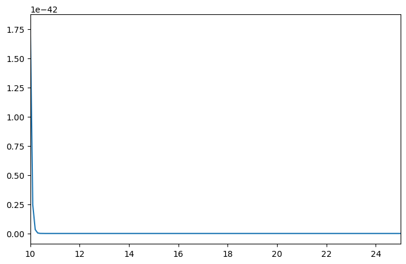

```python
def f1(x):
    return (x**2 - 5*x -2)*np.exp(-x**2)

xval = np.linspace(10.,25.,151)
yval = f1(xval)

fig, ax = plt.subplots(figsize=(8, 5))
ax.set_xlim(10., 25.)

ax.plot(xval, yval);
```

### Utilizzate un numero appropriato di punti

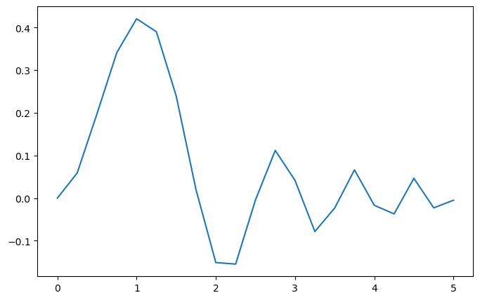

```python
def f2(x):
    return np.sin(x**2)/(1. + x**2)

xval = np.linspace(0.,5.,21)
yval = f2(xval)

fig, ax = plt.subplots(figsize=(8, 5))

ax.plot(xval, yval);
```

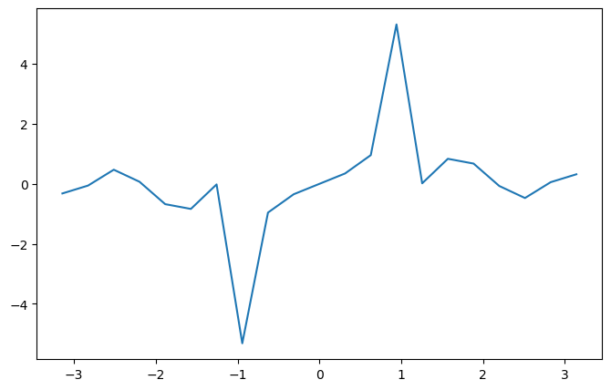

```python
def f3(x):
    return x*np.cos(x**2)/(1. - x**2)

xval = np.linspace(-np.pi,np.pi,21)
yval = f3(xval)

fig, ax = plt.subplots(figsize=(8, 5))

ax.plot(xval, yval);
```

## Plot multipli

### Curve multiple in un singolo plot

È sufficiente dare il comando `plot` su un singolo `ax` per tutte le curve da disegnare

```python
t = np.arange(0.0, 2*np.pi, 0.01)

fig, ax = plt.subplots(figsize=(12, 5))
ax.plot(t, np.cos(t), c='r')
ax.plot(t, np.cos(2*t), c='b')
ax.plot(t, np.cos(10*t), c='g')
```

### Plot multipli in una sola figura.

È necessario creare, nella chiamata a `plt.subplots`, tanti oggetti di tipo `ax` quanti sono i plot che si vogliono ottenere. Ciascuno dei comandi successivi si riferirà ad uno specifico oggetto `ax`.

```python
def f(t):
    return np.exp(-t) * np.cos(2*np.pi*t)


t1 = np.arange(0.0, 5.0, 0.1)
t2 = np.arange(0.0, 5.0, 0.02)

fig3, (ax3a, ax3b) = plt.subplots(nrows=1, ncols=2, figsize=(14, 5))

ax3a.plot(t1, f(t1), marker='o', c='b')
ax3a.set_xlabel('x value')
ax3a.set_ylabel('f(x)')
ax3a.set_title('Plot 1')

ax3b.plot(t2, np.cos(2*np.pi*t2), linestyle='--', c='r')
ax3b.set_xlabel('x value')
ax3b.set_ylabel('cos(2 pi x)')
ax3b.set_title('Plot 2')

fig3.tight_layout()

# Percontrollare lo spazio fra i plot potete usare fig3.tight_layout(pad=3.6)
# help(fig3.tight_layout) per ulteriori informazioni

# linestyle='-','--',':'
```

Per ottenere quattro plot in due file da due utilizzare:

```python
fig, ((ax1, ax2), (ax3, ax4)) = plt.subplots(nrows=2, ncols=2)
```

Un'altra possibilità è assegnare l'ntupla degli ax ad un unica variabile e poi utilizzare gli indici. In questo modo è possibile fare un ciclo `for` sui plot:

```python
fig1, my_ax = plt.subplots(nrows=2, ncols=2)
my_ax[0][1].plot(np.array([1, 2, 3]))
# oppure
my_ax[1,0].plot(np.array([1, 2, 1]))
```

### Titolo centrato per tutta la figura

```python
fig1, my_ax = plt.subplots(nrows=2, ncols=2)
my_ax[0, 1].plot(np.array([1, 2, 3]))
my_ax[0, 1].set_title("One line")
plt.suptitle("Four Plots with one line");
fig1.tight_layout()
```

## Salvare una figura in un file

L'estensione del file determina il formato in cui viene salvata la figura

```python
fig3.savefig('plot3.pdf')
fig3.savefig('plot3.jpg')
```

#### Imparare Facendo

1. Fate il grafico di y1(x) = cos(x)/(x**2+1) e y2(x) = (cos(x)+x)/(x**2+1) nell'intervallo -5 < x < 2 in un unico plot. Introducete nomi opportuni per gli assi. Inserite una griglia per semplificare la lettura del plot.
2. Fate il grafico di y1(x) = cos(x) e y2(x) = cos(x)+x nell'intervallo -2 < x < 2 in due plot affiancati. Utilizzate colori diversi per le due curve. Introducete nomi opportuni per gli assi di entrambi i plot.

## Plot logaritmici

Per avere una scala logaritmica sull'asse `x`, `y` si usano i metodi `set_xscale('log')`, `set_yscale('log')` sugli oggetti di tipo `AxesSubplot`

```python
fig4, (ax4a, ax4b) = plt.subplots(nrows=1, ncols=2, figsize=(14, 7))

t = np.arange(0.01, 20.0, 0.01)

# log y axis
ax4a.set_yscale('log')
ax4a.plot(t, np.exp(-t/5.0))
ax4a.set_xlabel('x value')
ax4a.set_ylabel('exp(-t/5.0)')
ax4a.set_title('semilogy')
ax4a.grid(visible=True, which='both')

# log x axis
ax4b.set_xscale('log')
ax4b.plot(t, np.sin(2*np.pi*t))
ax4b.set_xlabel('x value')
ax4b.set_ylabel('sin(2*pi*t)')
ax4b.set_title('semilogx')
ax4b.grid(visible=True, which='both')
```

Di default vengono utilizzati logaritmi in base 10. È possibile specificare una base diversa:

```python
t = np.arange(0.01, 20.0, 0.01)

fig5, ax5 = plt.subplots(nrows=1, ncols=1, figsize=(7, 7))

ax5.set_xscale('log', base=2)
ax5.set_yscale('log')
ax5.plot(t, t, c='r')
ax5.plot(t, t**2, c='b')
ax5.grid(visible=True, which='both')
ax5.set_title('loglog base 2 on x')
```

I plot logaritmici sono essenziali quando ordinate e/o ascisse variano su molti ordini di grandezza.

```python
t = np.arange(0.01, 10.0, 0.01)

fig6, (ax6a, ax6b) = plt.subplots(nrows=1, ncols=2, figsize=(10, 6))

ax6a.plot(t, t, c='r')
ax6a.plot(t, t**2, c='b')
ax6a.plot(t, t**4)
ax6a.set_title('linear')
ax6a.grid(visible=True, which='both')

ax6b.set_yscale('log')
ax6b.plot(t, t, c='r')
ax6b.plot(t, t**2, c='b')
ax6b.plot(t, t**4)
ax6b.set_title('y-log')
ax6b.grid(visible=True, which='both')
```

#### Imparare Facendo

1. Fate il grafico di y1(x) = np.e**(-x), y2(x) = np.e**(-2*x) nell'intervallo 0 < x < 10, in un unico plot, utilizzando una scala logaritmica per l'asse y. Introducete nomi opportuni per gli assi. Inserite una griglia per semplificare la lettura del plot.

## Istogrammi

I dati sono raggruppati in intervalli o bin (contenitori, bidoni) che ricoprono il range di possibili valori della variabile che si sta studiando. L'altezza di ciascun bin è proporzionale al numero di dati che cadono fra i due valori della variabile che definiscono la base del bin. Cambiando il numero di bin e/o i loro estremi si cambia il plot.

```python
dati = np.array([1.95, 1.96, 1.90, 1.90, 1.84, 1.81, 2.06, 1.99, 1.93, 1.97, 2.02, 1.92,
                 1.95, 1.88, 1.87, 2.03, 1.85, 2.08, 1.96, 1.81, 2.07, 1.91, 1.79, 1.99,
                 1.97, 1.95, 1.96, 1.93, 1.83, 2.09, 2.02, 2.09, 1.84, 1.86, 1.96, 2.03,
                 1.93, 1.90, 1.94, 1.87, 1.97, 1.91, 1.87, 1.81, 2.06, 2.02, 1.96, 1.81,
                 1.93, 2.03, 1.92, 1.96, 1.80, 1.95, 1.90, 2.02, 2.03, 1.90, 2.03, 2.02,
                 1.96, 1.91, 1.98, 1.87, 1.92, 1.89, 1.84, 2.06, 1.93, 2.06, 1.93, 1.93,
                 1.91, 1.90, 1.92, 1.93, 1.86, 1.83, 1.96, 1.81, 2.03, 1.98, 1.84, 1.86,
                 1.96, 1.81, 1.98, 1.84, 1.86, 1.96, 1.92, 1.96, 1.85, 2.04, 2.00, 1.92,
                 1.90, 2.15, 1.94, 1.92])
```

```python
nbins = 10
xrange = (1.75, 2.20)    # ntupla
```

```python
fig, ax = plt.subplots()
nevent, bins, patches = ax.hist(dati, nbins, range=xrange)     # Non è indispensabile assegnare i valori restituiti da `hist`  a
   # delle variabili. In questo caso ci serve per esaminarne il contenuto.

ax.set_xlabel('variable')
ax.set_ylabel('counts')
ax.set_title('counts vs variable')
```

```python
nevent       # Numero di eventi in ciascun bin
```

```python
bins         # Estremi dei bin
```

I patches sono i rettangoli (blu in questo caso) che vengono usati per disegnare l'istogramma.

#### Imparare Facendo

1. Fate l'istogramma dell'array a = np.array([22,87,5,43,56,73,55,54,11,20,51,5,79,31,27]). Qual'è un **range** ragionevole? Variate il numero di bin fra 1 e 10.

## Altri elementi dei plot

### Legende

La legenda per ciascuna curva viene passata con il parametro `label` nella chiamata a `plot`. Le legende vengono mostrate invocando il metodo `legend` sul singolo garfico. Le curve prive di `label` non vengono incluse nella legenda. Se viene chiamato `legend` e nessuna delle curve ha un `label` si ha un errore.

```python
xc = np.arange(-5.0, 5.0, 0.02)
```

```python
def g1(x):
    return x*(x-1)/(x**2+1)-1
```

```python
yc1 = g1(xc)
```

```python
def g2(x):
    return (x-1)/(x**2+1)
```

```python
yc2 = g2(xc)
```

```python
fig, ax = plt.subplots(figsize=(10, 8))
ax.set_title('g1=x*(x-1)/(x**2+1)-1, g2=(x-1)/(x**2+1)', fontsize='20')
ax.set_xlabel('x value')
ax.set_ylabel('g(x)')
ax.grid(True)
ax.margins(x=0., y=0.05)
ax.plot(xc, yc1, c='b', label='pippo rules', linestyle = '--');
ax.plot(xc, 3*yc2, 'k', label='g2');
ax.plot(xc, yc2, c='g');
ax.legend(fontsize='30');
```

### Testo

Il prefisso `r` davanti alle stringhe di testo inibisce l'interpretazione dei caratteri di "escape" come caratteri speciali. Importante perchè LaTeX usa il carattere "\" per introdurre i comandi e "\" è il carattere standard di "escape".

```python
def f0(t, omega, gamma, tau):
    wt = omega*t
    f1 = np.sin(wt) + (np.cos(wt)-1.0)/wt
    f2 = 1.0 + (gamma/omega)*f1
    return np.exp(-t*f2/tau)


omega = 12.0
gamma = 8.0
tau = 1.0

t = np.linspace(0.01, 10.0, 500)
f = f0(t, omega, gamma, tau)

fig, ax = plt.subplots(figsize=(7.5, 4.5))
ax.plot(t, f)
ax.set_ylabel(r'$f_0(t)$', fontsize=14)
#ax.set_ylabel('$f_0(t)$', fontsize=14)   # r è superfluo per questa stringa in cui non ci sono caratteri "escape"
ax.set_xlabel(r'$t/\tau\quad\rm(ms)}$', fontsize=14)
#ax.set_xlabel('$t/\tau\quad\rm(ms)}$', fontsize=14)       # r è necessario per questa stringa in cui compare
                                                           # il carattere "\" come parte di LaTeX
plt.text(1.8, 0.85, r'$\Gamma(z)=\int_0^\infty x^{z-1}e^{-x}dx$', {'color': 'k', 'fontsize': 14})
plt.text(4.0, 0.40, r'$\Gamma(z)=\int_0^\infty x^{z-1}e^{-x}dx$', {'color': 'b', 'fontsize': 20})
```

### Subplots

Il metodo `plt.axes` permette di creare un nuovo grafico specificando la sua posizione e le sue dimensioni.

```python
def my_f(x):
    return 2*x**3 + 3*x**2 - 12*x -10


xval = np.arange(-4, 3, 0.1)
yval = my_f(xval)

fig, ax = plt.subplots(figsize=(8, 6))

ax.set_xlabel('x coordinate')
ax.set_ylabel('my_f(x)')
ax.set_title('Plot of my_f')
ax.grid()

ax.plot(xval, yval);

ax2 = plt.axes([0.3, 0.2, 0.3, 0.2]) # [x_left_lower_corner,y_left_lower_corner,x_width,y_width]
                                     # Le coordinate si riferiscono alla intera figura
                                     # normalizzate fra 0 e 1

xval2 = np.arange(0, 2*np.pi, 0.1)
yval2 = np.cos(xval2)
ax2.grid()
ax2.plot(xval2, yval2);
```

## Plot parametrici

Spesso per descrivere una curva esprimiamo le coordinate `y` dei punti sulla curva in funzione delle loro coordinate `x`. Per esempio una semicirconferenza centrata nell'origine è descritta dalla relazione $ y(x) = \sqrt{r^2 - x^2}$, dove $r$ è il raggio.
Un modo alternativo di costruire i punti sul cerchio di raggio $r$ è di notare che possiamo usare come parametro o coordinata l'angolo del punto rispetto all'asse $\hat{x}$ come: $$ x(\theta) = r \cos\theta,\qquad y(\theta) = r \sin\theta$$ Se creiamo due array sufficientemente fitti in questo modo, possiamo disegnare una circonferenza nel modo seguente:

```python
raggio = 3.0
npoints = 100
step = 2*np.pi/npoints
x0 = raggio*np.array([np.cos(i*step) for i in range(npoints+1)])
y0 = raggio*np.array([np.sin(i*step) for i in range(npoints+1)])
```

```python
fig, ax = plt.subplots(figsize=(10, 10))
ax.plot(x0, y0)
```

Provate a vedere cosa succede per npoints = 3,4,8,12.

Un altro buon esempio è la traiettoria di una massa nel campo gravitazionale terrestre. Le coordinate `x` e `y` del moto in funzione del tempo sono:

```python
def x_of_t(t, vx0, x0=0.):
    return vx0*t + x0


def y_of_t(t, vy0, y0=0, g=9.8):
    return -0.5*t*t + vy0*t +y0


vx0 = 5.0
vy0 = 7.0
tmax = 800
times = np.array([t/50 for t in range(tmax+1)])

x = x_of_t(times, vx0)
y = y_of_t(times, vy0)

fig, ax = plt.subplots(figsize=(12, 12))
ax.grid()
ax.set_ylabel("y", {'fontsize':30})
ax.set_xlabel("x", {'fontsize':30})
ax.set_title("y(x) free fall", {'fontsize':40})

ax.plot(x, y);
```

E per concludere:

## Problema:

Studiare la funzione $g(x)\, = \, \cos \left( \frac{x^4 - 5 x^3 - 3 x^2 + 17 x - 10}{x^4 + 2 x^2 + 1} \right)$

#### Attenzione!

La possibilità di fare il grafico di una qualsiasi funzione con pochissima fatica richiede di cambiare completamente l'approccio che vi è stato insegnato alle scuole superiori sul modo di studiare le funzioni. Fare il grafico deve diventare il passo preliminare a qualsiasi altra manipolazione.

Informazini addizionali e buoni esempi: https://www.machinelearningplus.com/plots/matplotlib-tutorial-complete-guide-python-plot-examples/

# Sommario 8: Grafici con Matplotlib - Guida Essenziale

## I Concetti Fondamentali

### La Struttura Base: Figure e Axes

```
fig, ax = plt.subplots()  # Una figura, un grafico
```

- **Figure**: La tela/pagina intera
- **Axes**: Il singolo grafico (assi + area di plot)
- **Regola**: Un `fig` può contenere multipli `ax`

### I Due Metodi Principali

| `plot()` | `scatter()` |
| --- | --- |
| Linee che connettono punti | Punti isolati |
| Per funzioni continue | Per dati sperimentali |
| Default: linea senza marker | Default: marker senza linea |

## Il Workflow Standard per un Grafico

### 1. Preparazione dei Dati

```
x = np.linspace(start, stop, n_points)
y = funzione(x)
```

### 2. Creazione della Figura

```
fig, ax = plt.subplots(figsize=(largh, alt))
```

### 3. Plot dei Dati

```
ax.plot(x, y, color='b', linestyle='-', label='nome')
```

### 4. Personalizzazione

```
ax.set_xlabel('Tempo (s)')
ax.set_ylabel('Posizione (m)')
ax.set_title('Moto Armonico')
ax.grid(True)
ax.legend()
```

### 5. Salvataggio (opzionale)

```
fig.savefig('nome.pdf')
```

## Personalizzazione: I Parametri Chiave

### Colori e Stili

- **Colori**: `'r'` (rosso), `'b'` (blu), `'g'` (verde), `'k'` (nero)
- **Linee**: `'-'` (solida), `'--'` (tratteggiata), `':'` (puntini), `'-.'` (tratto-punto)
- **Marker**: `'o'` (cerchi), `'s'` (quadrati), `'^'` (triangoli), `'.'` (punti)

### Controllo degli Assi

```
ax.set_xlim(xmin, xmax)  # Limiti manuali
ax.set_ylim(ymin, ymax)
ax.grid(True)             # Griglia
ax.set_aspect('equal')    # Rapporto aspetto
```

## Plot Multipli: Le Tre Situazioni

### 1. Più Curve nello Stesso Plot

```
ax.plot(x, y1, label='curva 1')
ax.plot(x, y2, label='curva 2')
ax.legend()
```

### 2. Subplot Affiancati

```
fig, (ax1, ax2) = plt.subplots(1, 2)
ax1.plot(x, y1)
ax2.plot(x, y2)
```

### 3. Subplot in Griglia

```
fig, axes = plt.subplots(2, 2)
axes[0,0].plot(...)  # Alto sinistra
axes[0,1].plot(...)  # Alto destra
```

## Scale Logaritmiche: Quando e Come

### Quando Usarle

- Dati che variano su ordini di grandezza
- Decadimenti esponenziali
- Leggi di potenza

### Come Applicarle

```
ax.set_xscale('log')  # Solo x logaritmico
ax.set_yscale('log')  # Solo y logaritmico
# Entrambi logaritmici = log-log plot
```

## Grafici Specializzati

### Istogrammi

```
n, bins, patches = ax.hist(dati, bins=n_bins, range=(min, max))
```

**Uso**: Distribuzione di dati sperimentali

### Plot Parametrici

```
t = np.linspace(0, 2*np.pi, 100)
x = r * np.cos(t)
y = r * np.sin(t)
ax.plot(x, y)
```

**Uso**: Traiettorie, orbite, curve complesse

## Pattern Utili per la Fisica

### Confronto Teoria-Esperimento

```
ax.scatter(x_exp, y_exp, label='Sperimentale')
ax.plot(x_teo, y_teo, 'r-', label='Teorico')
ax.legend()
```

### Oscillazioni Smorzate

```
t = np.linspace(0, 10, 1000)
y = A * np.exp(-gamma*t) * np.cos(omega*t)
ax.plot(t, y)
ax.plot(t, A*np.exp(-gamma*t), 'r--')  # Inviluppo
```

## Errori Comuni e Soluzioni

| Problema | Sintomo | Soluzione |
| --- | --- | --- |
| Output `[<matplotlib...>]` | Manca `;` alla fine | Aggiungi `;` dopo plot |
| Grafico vuoto | Dati fuori scala | Controlla `xlim`, `ylim` |
| Legenda error | Nessun `label` | Aggiungi `label='nome'` |
| Testo LaTeX non funziona | `\` interpretato male | Usa `r'stringa'` |
| Plot sovrapposti | `subplots` errato | Verifica `nrows`, `ncols` |

## Best Practices

### 1. Sempre Etichettare gli Assi

```
ax.set_xlabel('Grandezza (unità)')
```

### 2. Griglia per Leggibilità

```
ax.grid(True, alpha=0.3)
```

### 3. Legende per Plot Multipli

```
ax.plot(..., label='descrizione')
ax.legend(loc='best')
```

### 4. Figure di Dimensioni Appropriate

- Schermo: `figsize=(10, 6)`
- Paper: `figsize=(8, 6)`
- Presentazione: `figsize=(12, 8)`

## Checklist Pre-Consegna

- Assi etichettati con unità di misura?
- Titolo descrittivo?
- Legenda se ci sono più curve?
- Font leggibili (non troppo piccoli)?
- Colori distinguibili?
- Scala appropriata (lineare vs log)?
- Griglia se aiuta la lettura?

## Il Consiglio Più Importante

**PRIMA grafica, POI analizza**: Fare sempre un plot esplorativo prima di qualsiasi manipolazione matematica. Un grafico vale più di mille calcoli per capire il comportamento di una funzione o di un dataset.